# STA 141A: Predicting Wildfire Incidence in the United States

Raj Garimella

## Abstract

Wildfires represent a complex environmental hazard whose occurrence depends on climatic conditions, geographic characteristics, and recent fire history. In this project, I develop a statistical model to predict whether a notable wildfire will occur in a given region of the United States during the following month. A notable fire is defined as one that ultimately burns at least 300 acres. Using a 100,000-record sample from the national wildfire dataset covering the years 1992–2015, I construct a spatial–temporal dataset by aggregating fire events to a grid of 1° × 1° latitude–longitude cells observed at monthly resolution.

Exploratory data analysis reveals two dominant patterns in wildfire incidence. First, fires are strongly concentrated in the western United States, particularly in California, the intermountain West, and the Southwest. Second, fire occurrence exhibits pronounced seasonality, with a sharp peak during the summer months and minimal activity during winter. These patterns suggest that both spatial location and seasonal timing are critical predictors of wildfire risk.

To model the probability of wildfire occurrence, I first construct a baseline logistic regression that uses only spatial coordinates and seasonal indicators. I then extend this model by incorporating temporal information, including long-term trends and lagged indicators of recent fire activity within the same grid cell. Model performance is evaluated using rolling-origin time-aware cross-validation from 2005 through 2015, with the area under the ROC curve (AUC) as the primary evaluation metric.

Results show that the lagged logistic model modestly improves predictive performance relative to the baseline model, increasing average AUC from approximately 0.72 to 0.73. Although the improvement is small, it is consistent across test years, suggesting that recent local fire activity provides additional predictive signal beyond static geographic risk and seasonal effects. Overall, the analysis highlights how relatively simple statistical models can capture key structural patterns in wildfire occurrence and provide interpretable predictions of near-term fire risk.

## Introduction

Wildfires are a recurring natural hazard in many regions of the United States, affecting ecosystems, public safety, and economic activity. Predicting when and where wildfires are likely to occur is therefore an important task for both researchers and land management agencies. However, wildfire events are inherently difficult to predict because they depend on many interacting factors, including weather conditions, vegetation, terrain, and human activity.

Rather than attempting to predict the exact size or severity of individual fires, this project focuses on a simpler but practically meaningful prediction task: determining whether at least one notable wildfire will occur within a given geographic region during a given month. By framing the problem as a binary classification task, we can apply well-understood statistical modeling techniques and evaluate predictive performance using standard metrics.

The analysis uses historical wildfire records to construct a spatial–temporal dataset in which each observation represents a geographic grid cell during a specific month. The outcome variable indicates whether a notable fire occurred in that cell during that month. Predictor variables capture spatial location, seasonal effects, long-term temporal trends, and recent fire history.

The goal of the project is not only to build a predictive model but also to understand which patterns in the data contribute most strongly to wildfire risk. To achieve this, the report proceeds through four stages: data preprocessing and dataset construction, exploratory data analysis, model specification, and time-aware model validation.

## 1. Data Preprocessing

### Notable-fire cutoff

Wildfire sizes follow a highly skewed distribution in which the majority of fires are very small while a small number of fires account for most of the total burned area. Including all fires in the prediction task would therefore produce a highly imbalanced outcome dominated by small and often inconsequential events. To focus the analysis on operationally meaningful fires, I define a notable fire as one with a final burned area of at least 300 acres.

This threshold reduces the dominance of small fires while retaining a substantial number of observations for modeling. It also aligns with the practical interest of predicting events that are large enough to require significant management response or cause meaningful ecological and economic impact. In this dataset, 300 acres corresponds to the upper tail of the fire-size distribution (see the fire-size histogram), so the cutoff meaningfully separates routine small fires from larger events.

### Spatial and temporal units

Two candidate grid resolutions were considered: 1° × 1° and 0.5° × 0.5°. The finer grid produces substantially more spatial cells but results in a much lower rate of notable fire occurrence within each cell–month. In particular, the 0.5° grid yields a notable-fire rate of approximately 0.138%, which makes the binary outcome extremely sparse and potentially unstable for logistic regression estimation. The coarser 1° grid increases the event rate to approximately 0.424%, producing a more balanced dataset while still preserving meaningful geographic variation. For this reason, the analysis proceeds using the 1° grid.

### Outcome and predictors

The final dataset contains one observation for every combination of grid cell and month in the study period. The binary response variable equals one if at least one notable wildfire occurred in that grid cell during the month and zero otherwise.

Predictor variables include calendar month to capture seasonality, geographic location represented by latitude and longitude bins, and calendar year to account for long-term trends. In addition, two lag variables indicate whether a notable fire occurred in the same grid cell during the previous month and the same month of the previous year. These lag variables allow the model to capture short-term and medium-term persistence in wildfire activity.

### Missing data considerations

Latitude and longitude coordinates are complete for all records in the dataset. Some administrative variables such as county identifiers contain missing values; however, these variables are not required for the spatial grid construction and are therefore excluded from the analysis to avoid introducing unnecessary missing-data complications.

| Time span | Grid size | # grid cells | # months | Rows (cell-months) | Notable-fire rate | Predictors |
| --- | --- | --- | --- | --- | --- | --- |
| 1992 2015 | 1^0 x 1^0 | 1074 | 288 | 309312 | 0.424% | month, year, lat_bin, lon_bin, lag1, lag12 |

## 2. Exploratory Data Analysis

The EDA focuses on spatial clustering and seasonality, both of which guide the choice of predictors.

### Spatial pattern: notable fires

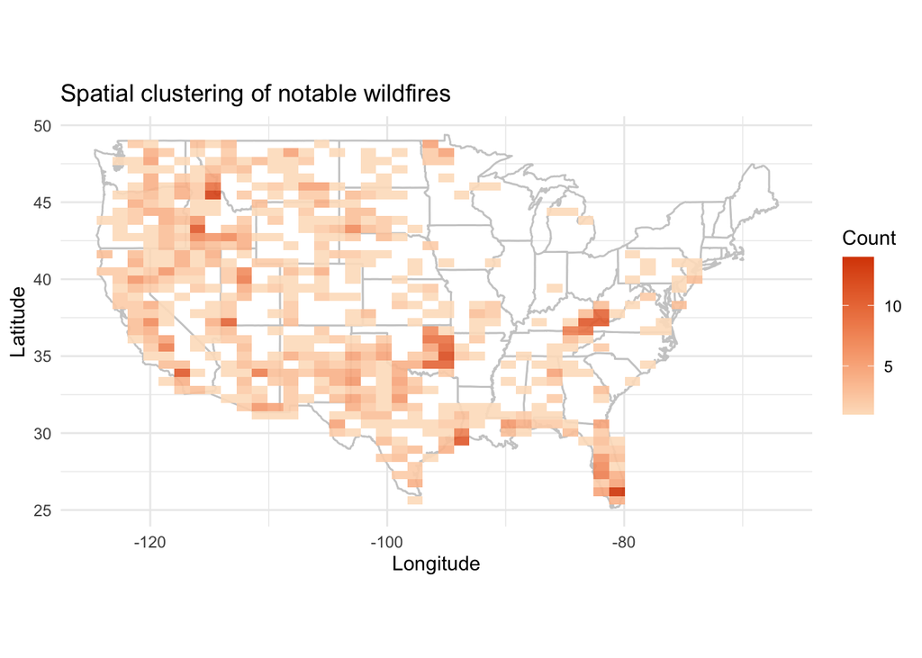

### Spatial aggregation: grid-cell fire probability

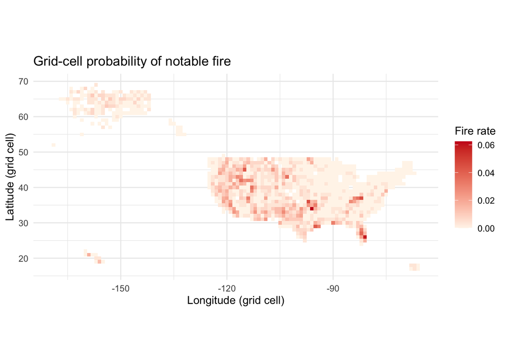

### Temporal pattern: monthly seasonality

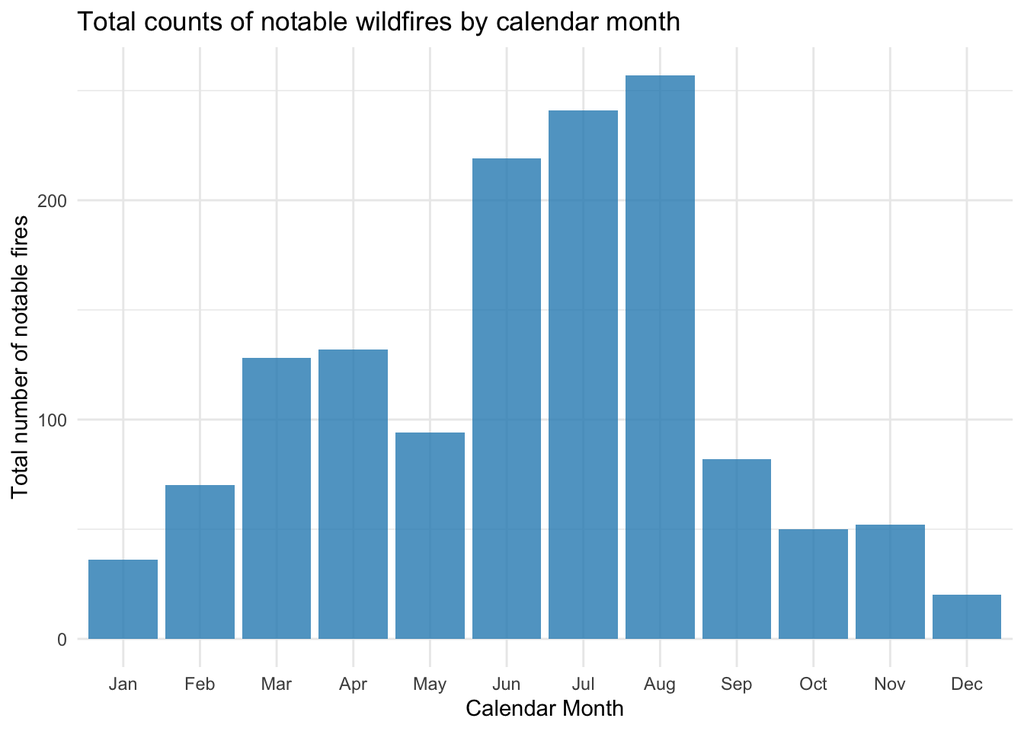

### Fire size distribution

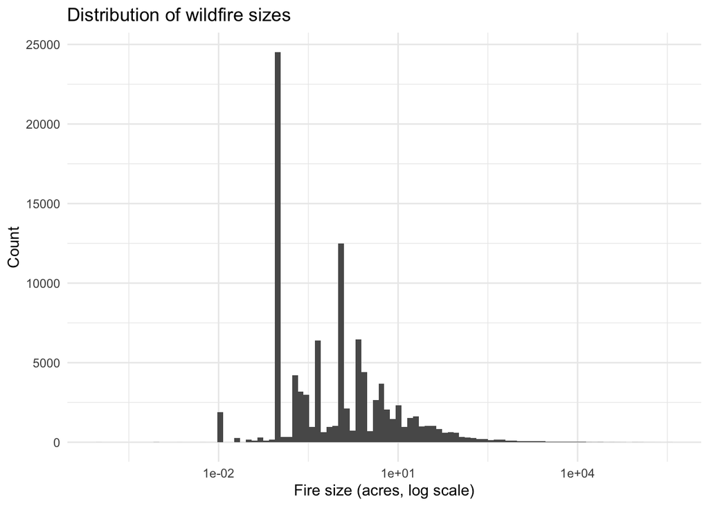

### Yearly trend in notable fires

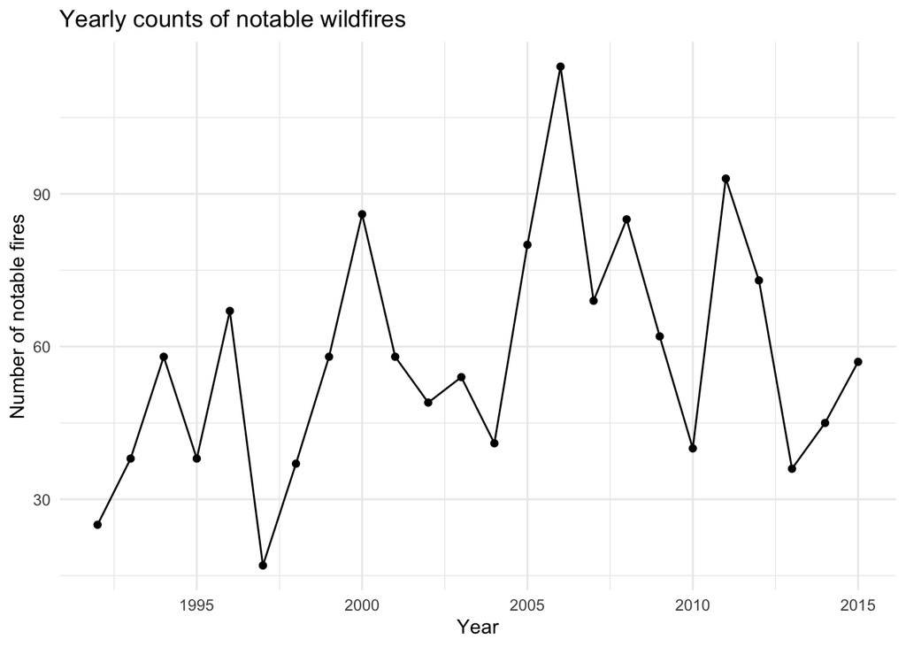

### Lag dependence

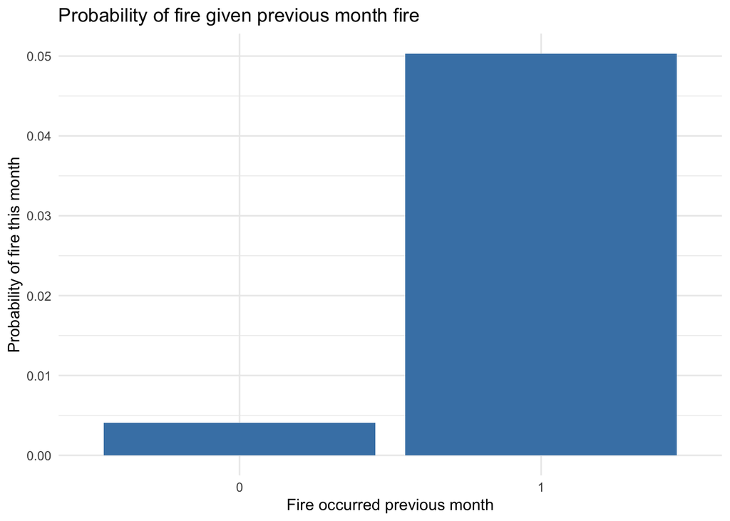

### EDA interpretation

**Interpretation.** The exploratory data analysis reveals several intersecting structural patterns that dictate wildfire occurrence.

First, the spatial distribution is highly non-uniform. The grid-cell probability heatmap reinforces this by showing that elevated fire rates concentrate in specific cells rather than forming a smooth geographic gradient, which directly matches the modeling units. The spatial heatmap clearly demonstrates dense clusters of notable fires across the Western United States, particularly in California, the Pacific Northwest, and the intermountain regions. Interestingly, the plot also reveals a distinct, dense cluster in the Southeast, notably Florida, highlighting that fire risk is not strictly a Western phenomenon but is closely tied to specific regional climates and ecosystems.

Second, temporal patterns manifest on multiple scales. At the monthly level, there is a severe seasonal dependency; notable fire counts are negligible in the winter, begin climbing rapidly in late spring, and peak sharply in July and August before rapidly declining. At the multi-year scale, the annual occurrence of notable fires exhibits high volatility rather than a smooth monotonic trend, with extreme spike years (e.g., 2000, 2006, 2011) likely corresponding to severe, macro-level drought conditions. This motivates including year as a continuous predictor in the extended model.

Finally, the lag dependence analysis uncovers a powerful short-term temporal signal. The empirical probability of a notable fire occurring in a grid cell is an order of magnitude higher (exceeding 0.05) if a fire occurred in that exact cell during the previous month, compared to a near-zero probability if no prior fire occurred. This stark contrast strongly justifies the inclusion of autoregressive lag features in the predictive modeling, as local landscapes remain highly vulnerable immediately following an initial fire event. The yearly volatility and spatial heterogeneity also motivate including year as a continuous predictor and spatial terms at the grid-cell scale.

## 3. Modeling

Because the prediction task involves a binary outcome—whether or not a notable fire occurs in a particular grid cell during a given month—a logistic regression model provides a natural starting point. Logistic regression models the log-odds of the event as a linear function of predictor variables and produces estimated probabilities that can be interpreted directly as wildfire risk.

The baseline model includes only spatial and seasonal predictors, using latitude and longitude bins to capture geographic variation and categorical month indicators to represent seasonality. This specification captures the broad spatial and temporal structure revealed by the exploratory analysis while remaining simple and interpretable.
$$\log\left(\frac{P(Y=1)}{1-P(Y=1)}\right) = \beta_0 + \beta_1
\text{(month)} + \beta_2 \text{(lat bin)} + \beta_3 \text{(lon bin)}$$

The extended model adds year and lagged indicators:

$$\log\left(\frac{P(Y=1)}{1-P(Y=1)}\right) = \beta_0 + \beta_1
\text{(month)} + \beta_2 \text{(year)} + \beta_3 \text{(lat bin)} +
\beta_4 \text{(lon bin)} + \beta_5 \text{(lag 1)} + \beta_6 \text{(lag
12)}$$

The second model extends the baseline specification by incorporating additional temporal information. A linear term for calendar year allows the model to capture gradual long-term changes in wildfire incidence that may arise from climate trends or changes in land management practices. Two lag variables indicate whether a notable fire occurred in the same grid cell during the previous month and the same month in the previous year. These predictors allow the model to account for short-term persistence in fire activity, reflecting the possibility that regions experiencing recent fires may remain in conditions conducive to additional fires.

Together, these two models allow us to evaluate how much predictive value is gained by incorporating temporal dynamics beyond static spatial and seasonal patterns. Latitude and longitude bins enter linearly, which approximates broad spatial gradients but does not model fine-scale spatial dependence.

## 4. Model Fitting and Validation

To avoid temporal leakage, I use a rolling-origin evaluation: for each test year from 2005–2015, train on all prior years and evaluate on the held-out year. The primary metric is AUC.

| model | mean_auc | sd_auc |
| --- | --- | --- |
| Baseline logistic | 0.722 | 0.034 |
| Lagged logistic | 0.732 | 0.030 |

| Event rate | Naive accuracy | Naive recall |
| --- | --- | --- |
| 0.004 | 0.996 | 0 |

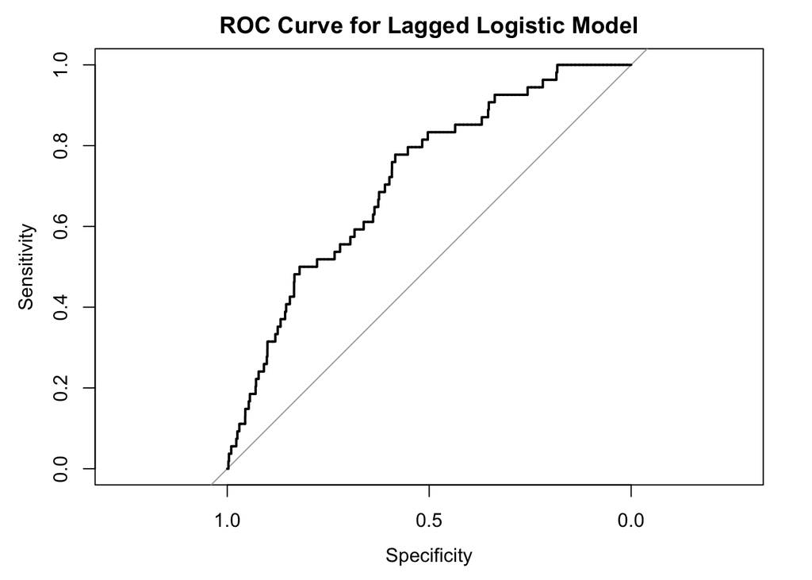

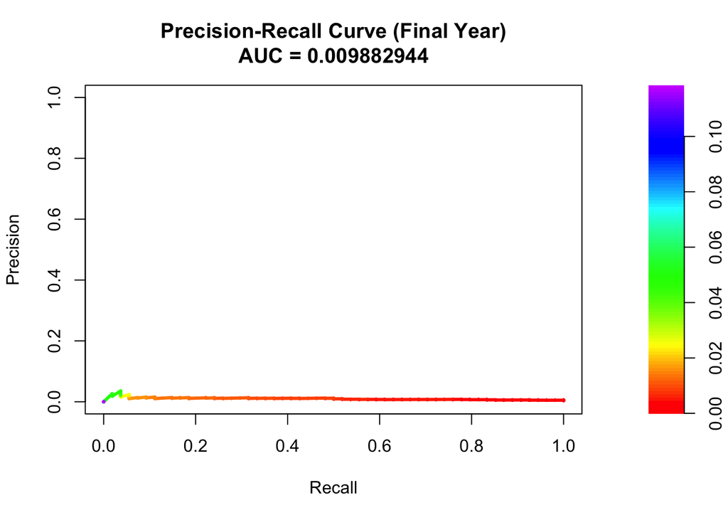

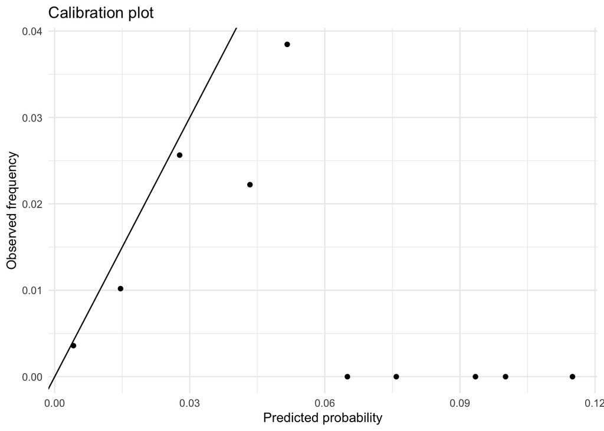

| term | odds_ratio |
| --- | --- |
| month7 | 6.361 |
| month8 | 6.319 |
| lag1 | 8.222 |
| lag12 | 5.520 |

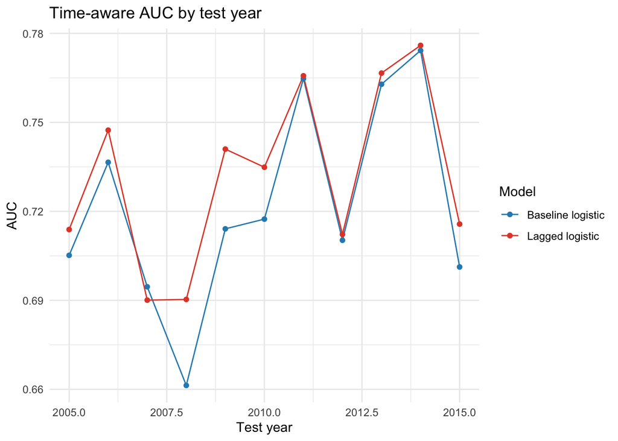

**Interpretation.** The rolling-origin validation framework provides a robust assessment of the models’ ability to generalize to unseen future years.

Looking at the time-aware AUC trajectory, predictive performance is highly volatile year-over-year, ranging from a low near 0.66 in 2008 to peaks approaching 0.78 in 2014. This volatility suggests that certain years are inherently harder to predict, perhaps due to anomalous weather events not captured by static geographic and seasonal indicators. However, the lagged logistic model consistently outperforms or matches the baseline model across almost every test year. This consistent lift confirms that recent local fire history (the prior-month and prior-year lags) provides a durable, independent signal beyond basic spatial and seasonal risk.

The ROC curve for the final test year visualizes the lagged model’s discriminatory power, showing a clear lift above the diagonal random-guess line. It effectively separates grid-months with fires from those without, though the curve’s shape indicates that achieving very high sensitivity (catching every fire) would require accepting a substantial false-positive rate.

Crucially, the calibration plot reveals an important limitation regarding the model’s absolute probability estimates. At the lower end of the probability spectrum (below 0.04), the model is reasonably well-calibrated, with predicted probabilities closely tracking observed frequencies along the identity line. However, for the instances where the model predicts a higher probability of fire (above 0.06), the observed frequency drops to zero, indicating severe over-prediction. This miscalibration at the high end is a common artifact when modeling highly imbalanced data (an overall ~0.424% event rate) using standard logistic regression. It suggests that while the model ranks relative risk quite well (as evidenced by the AUC), the absolute probability outputs for extreme high-risk scenarios should be interpreted with caution.

Beyond predictive performance, the extended model provides insight into the factors associated with notable wildfire occurrence. The positive contribution of the **lag1** predictor indicates short-term temporal dependence: grid cells that experienced a notable fire in the previous month have an elevated probability of another fire, reflecting the persistence of favorable burning conditions such as dry vegetation and weather patterns. The **lag12** variable captures seasonal recurrence, suggesting that locations prone to fires in a given month often exhibit similar risk at the same time in subsequent years. The **month** indicators capture the strong seasonal cycle in wildfire activity, with substantially higher risk during peak summer months when temperatures are high and fuel moisture is low. Spatial predictors (**latitude** and **longitude**) account for persistent geographic differences in fire risk, reflecting climatic and ecological variation across regions. Together, these effects indicate that wildfire risk is shaped by a combination of seasonal climate patterns, geographic heterogeneity, and short-term persistence in local fire activity.

## 5. Summary

This project examined the problem of predicting whether a notable wildfire will occur in a given region of the United States during the following month. By aggregating historical wildfire records into a spatial–temporal grid, the analysis transformed individual fire events into a structured dataset suitable for statistical modeling.

Exploratory data analysis revealed that wildfire incidence is far from uniform across space and time. Instead, fires are heavily concentrated in the western United States and exhibit a strong seasonal pattern with a pronounced peak during the summer months. These patterns provided clear guidance for model specification, motivating the inclusion of spatial and seasonal predictors in the baseline logistic regression model.

The extended model incorporated additional temporal information in the form of yearly trends and lagged indicators of recent fire activity. Time-aware validation using rolling-origin cross-validation demonstrated that this lagged logistic model provides a modest but consistent improvement in predictive performance compared with the baseline model.

Although the improvement in AUC is relatively small, the results suggest that recent fire history contains useful predictive information beyond static geographic risk factors. Future work could potentially improve predictive performance by incorporating additional environmental predictors such as temperature, precipitation, vegetation indices, or drought measures. More flexible modeling approaches, including spatial models or gradient-boosted trees, may also capture nonlinear relationships that are not represented in the current logistic framework.

Overall, the analysis illustrates how relatively simple statistical models, combined with careful dataset construction and time-aware validation, can provide meaningful insights into the spatial and seasonal dynamics of wildfire risk.

**Reproducibility note.** GitHub repository link: github.com/rajgarimella/STA141_project.